# Lab 1

1. Aesthetics is **Individuals using the Internet** on the x-axis, **GDP/capita** on the y-axis, colored by **World Regions** with the size of the points determined by **Income**

|  | internet_users | gdp | income | year | country | four_regions | six_regions | eight_regions | world_bank_region |
| --- | --- | --- | --- | --- | --- | --- | --- | --- | --- |
| 0 | 0.00456 | 330.0 | 1190.0 | 2001 | Afghanistan | asia | south_asia | asia_west | South Asia |
| 1 | 0.39000 | 2570.0 | 6780.0 | 2001 | Albania | europe | europe_central_asia | europe_east | Europe & Central Asia |
| 2 | 1.59000 | 3770.0 | 9230.0 | 2001 | Algeria | africa | middle_east_north_africa | africa_north | Middle East & North Africa |
| 3 | NaN | 10500.0 | NaN | 2001 | American Samoa | NaN | NaN | NaN | NaN |
| 4 | 11.30000 | 42600.0 | 35600.0 | 2001 | Andorra | europe | europe_central_asia | europe_west | Europe & Central Asia |
| ... | ... | ... | ... | ... | ... | ... | ... | ... | ... |
| 210 | 1.85000 | 847.0 | 3270.0 | 2001 | Vietnam | asia | east_asia_pacific | east_asia_pacific | East Asia & Pacific |
| 211 | 27.50000 | 36700.0 | NaN | 2001 | Virgin Islands (U.S.) | NaN | NaN | NaN | NaN |
| 212 | 0.51900 | 1190.0 | 4940.0 | 2001 | Yemen | asia | middle_east_north_africa | asia_west | Middle East & North Africa |
| 213 | 0.47800 | 991.0 | 2080.0 | 2001 | Zambia | africa | sub_saharan_africa | africa_sub_saharan | Sub-Saharan Africa |
| 214 | 1.10000 | 1330.0 | 3190.0 | 2001 | Zimbabwe | africa | sub_saharan_africa | africa_sub_saharan | Sub-Saharan Africa |

215 rows × 9 columns

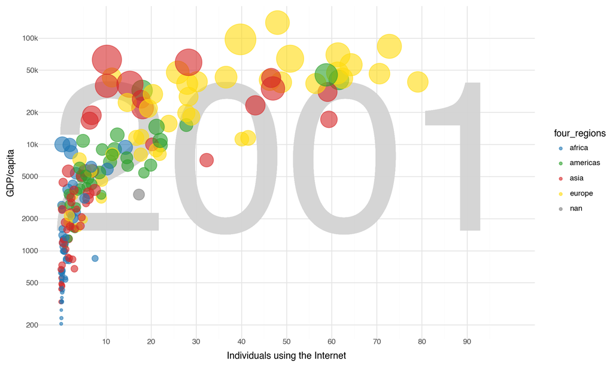

```python
# Task 3
from plotnine import *

# code structure reused from task 1 which was initially written by ChatGPT
(
    ggplot(df3,
        aes(
            x='internet_users',
            y='gdp',
            size='income',
            color='four_regions'
        ))
    + geom_text(aes(x=50, y=5000), label="2001", color="lightgrey",
             size=250, alpha=0.07)
    + geom_point(alpha=0.6)  # Add transparency to bubbles
    + scale_x_continuous(limits=(0, 100),
                      breaks=[10, 20, 30, 40, 50, 60, 70, 80, 90],
                      labels=['10', '20', '30', '40', '50', '60', '70', '80', '90'])
    + scale_y_continuous(trans='log2',
                        limits=(0,200000),
                        breaks=[200, 500, 1000, 2000, 5000, 10000, 20000, 50000, 100000],
                        labels=["200", "500", "1000", "2000", "5000", "10k", "20k", "50k", "100k"])
    + scale_size(range=(1, 20))  # Adjust size range for bubbles
    + scale_color_manual(values=["#1f77b4", "#2ca02c", "#d62728", "#ffdb0e"])
    + labs(x="Individuals using the Internet", y="GDP/capita")
    + guides(size=False) # removes size in legend
    + theme_minimal()
    + theme(figure_size=(10, 6))
)
```

Below is a data visualization using geom_line instead of geom_point to represent the same data.

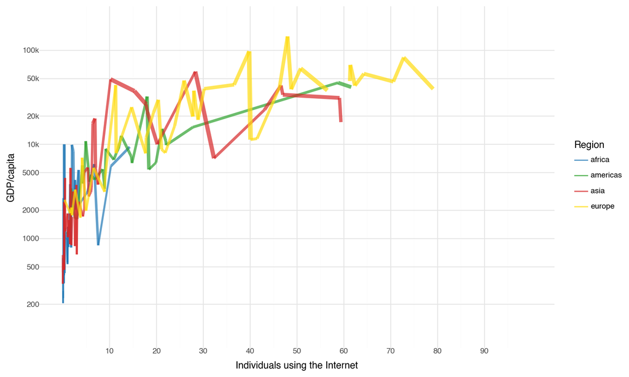

```python
# ChatGPT initially wrote this code
from plotnine import *

df3['gdp'] = pd.to_numeric(df3['gdp'], errors='coerce')

# Grouping by 'internet_users' and 'four_regions', calculating mean GDP and income
df3_summary = df3.groupby(['internet_users', 'four_regions']).agg({'gdp': 'mean', 'income': 'mean'}).reset_index()

(
    ggplot(df3_summary,
        aes(
            x='internet_users',
            y='gdp',
            group='four_regions',
            color='four_regions',
            size='income'
        ))
    + geom_line(alpha=0.7)
    + scale_x_continuous(limits=(0, 100),
                         breaks=[10, 20, 30, 40, 50, 60, 70, 80, 90],
                         labels=['10', '20', '30', '40', '50', '60', '70', '80', '90'])
    + scale_y_continuous(trans='log2',
                         limits=(100, 200000),
                         breaks=[200, 500, 1000, 2000, 5000, 10000, 20000, 50000, 100000],
                         labels=["200", "500", "1000", "2000", "5000", "10k", "20k", "50k", "100k"])
    + scale_color_manual(values=["#1f77b4", "#2ca02c", "#d62728", "#ffdb0e"])
    + scale_size(range=(1, 3))
    + labs(x="Individuals using the Internet", y="GDP/capita", color="Region", size="Average Income")
    + guides(size=False)
    + theme_minimal()
    + theme(figure_size=(10, 6))
)
```

This visualization is a line chart created by geom_line. This visualization does show a similar graphic to what geom_point does. We can look at the thickness of each line to determine the size of income according to the region. This visualization represents the data semi-well. It shows us the GDP/capita according to each regions number of internet users and even represents income well enough. An issue with this visualization is it is difficult to distinguish the different lines and regions near 0 on the x-axis. However a benefit of using geom_line is that we can see trends clearly in how GDP/capita changes as internet users differ accross different regions.

This lab did use ChatGPT and Gemini for code structure and conceptual questions regarding Python.